# Tutorial: RDME- Bimolecular Reaction

## 0.Environment Check

if you didn't install the environments in docker or any container, we suggest you do it through anaconda/miniconda.

basically, you need to install the dependencies

```
conda env create -f rdme_env.yml
```

Then import jLM package.

```python
import jLM                                  # Set up the Jupyter environment
from jLM.RDME import Sim as RDMESim         # Main simulation class
from jLM.RegionBuilder import RegionBuilder # Deal with the spatial geometry
from lm import IntMpdRdmeSolver             # lm::rdme::IntMpdRdmeSolver

import numpy as np
```

# 1. Initialization

## 1.1 RDME simulation object creation

First step is to create a object that contains all the essential information to start a simulation.

The class we use here is:

```
sim = jLM.RDME.Sim(simulation_name,
                    filename,
                    dimensions,
                    latticeSpacing,
                    regionName,
                    dt=None)
```

- simulation_name is what we call our system;
- filename: the name of the final output trajectory file.(hdf5 format)
- dimensions: the number of lattices in x,y,z dimension. in list [dimx,dimy,dimz], must be divisible by 32.
- latticeSpacing: the actual physical representation of the length of each subvolume cube, unit: meter.
- the Name of the entire sim region, default="external"
- dt: time steps for the RDME simualtion, unit: second.

```python
cellvol = 1.0e-15                # L=dm^3
simname = "Bimolecular_System"
filename = "T1_bimolecular.lm "
Ldim = [64,64,64]                   # Has to be multiples of 32
lattice_spacing = 32e-9            # in m
regionN = "extracellular"
dt = 25e-6                          # in s
```

```python
sim = RDMESim(  simname,
                filename,
                Ldim,
                lattice_spacing,
                regionN,
                dt)
```

in case you forget, or want to redefine some key parameters in the simulation we define above, you can always call methods to adjust them.

for example, we can change the simulation time step by:

```python
sim.timestep = 50e-6
```

next we need to define the total simulation time, the time interval to write results to our trajectory for lattice and species, normally we keep them the same.

Be careful, the unit for Interval is "time steps", and should be an integer.

The actual physical time for interval would be: $$ t = Interval * dt $$ since we define $dt=50 \times 10^{-6} s$, the actual write interval would be:

$$ 20000 * 50 \times 10^{-6} = 1s $$

```python
sim.simulationTime=10.0     # unit is seconds

sim.latticeWriteInterval= int(20000)    # unit is timesteps, dt
sim.speciesWriteInterval= int(20000)    # unit is timesteps, dt
```

## 1.2 Spatial Geometry Initialization

now, we need to add more spatial compartments to our system, for simplicity, our first toy system would only have three spatial regions:

- extracellular
- cytoplasm
- plasm membrane

we want each of them mutually excluded, and if we combine them all together, it should be the entire lattice sites we create:

$$\mathtt{lattice} = \mathtt{extracellular} \cup \mathtt{membrane}\cup \mathtt{cytoplasm} $$

and naturally $$\emptyset= \mathtt{membrane} \cap \mathtt{cytoplasm}$$ $$\emptyset= \mathtt{membrane} \cap \mathtt{extracellular}$$ $$\emptyset= \mathtt{cytoplasm} \cap \mathtt{extracellular}$$

In order to design the site lattice geometry, we create a `RegionBuilder` object, which reads the lattice dimensions from our simulation object `sim`.

```python
build = RegionBuilder(sim)
```

```python
cytoplasm = build.ellipsoid(radius = 20, center = [32,32,32])
```

Then we dilate the cytoplasm, and create a surface with the dilation method, and exclude the cytoplasm to represent our membrane

```python
cytoplasm_dilation = build.dilate(cytoplasm, se = build.se26)
membrane = cytoplasm_dilation & ~cytoplasm
```

Finally, make sure our extracellular region excludes the cell.

```python
# effectively, cytoplasm_dilation = cytoplasm and  membrane
extracellular = ~cytoplasm_dilation
```

we need our simulation system to compose all the regions together.

```python
cyt = sim.region('cytoplasm')
mem = sim.region('membrane')
ext = sim.region('extracellular')
```

```python
build.compose(
    (sim.region('extracellular'), extracellular),
    (sim.region('cytoplasm'), cytoplasm),
    (sim.region('membrane'), membrane))
```

wonderful, now we have all the geometric infomation, we can visualize it in two different ways: stacks and 3D

```python
sim.showRegionStack()
```

Key

- extracellular

- cytoplasm

- membrane

*xz*-plane; *y*-index=26

[figure not shown]

```python
sim.displayGeometry()
```

Key bindings

| Key binding | Function |
| --- | --- |
| `e` | Examine mode |
| `f` | Fly mode |
| `w` | Walk mode |
| `l` | Look mode |
| `r` | Reset view |
| `a` | Show all |
| `u` | Upright |

Examine mode

| Key binding | Function |
| --- | --- |
| Left-click / Shift+Left-click | Rotate |
| Middle-click / Ctrl+Left-click | Pan |
| Right-click / Alt+Left-click | Zoom |
| Double-click | Set center of rotation |

Fly mode

| Key binding | Function |
| --- | --- |
| Left-click | Move forward |
| Right-click | Move backward |

Walk mode

| Key binding | Function |
| --- | --- |
| Left-click | Move forward |
| Right-click | Move backward |

Look mode

| Key binding | Function |
| --- | --- |
| Left-click | Move closer |
| Right-click | Move back |

- extracellular

- cytoplasm

- membrane

## 1.2 Species and diffusion Co. Initialization

Our Template will be a reversible reaction as:

$$ A + B \rightleftharpoons C $$

However, our software only accept one-way reaction, we need to separate it into two irreversible reactions:

$$ A + B \xrightarrow{k_f} C $$$$ C \xrightarrow{k_r} A + B$$

initial condition:

# A = 1000

# B = 1000

# C = 0

```python
spA = sim.species('A')
spB = sim.species('B')
spC = sim.species('C')
```

- function references:

`sim.species((str)name, [(str,latex)textPepr, (str)annotation])`

Then you can call the following function to check the relevant info about your species:

```python
sim.showAllSpecies()
```

Select species

$\mathrm{A}$

| Index | `1` |
| --- | --- |
| Label | `A` |
| Total counts | 0 |
| Total reactions | 0 |

Diffusion rates

|  |  | Destination |  |  |
| --- | --- | --- | --- | --- |
|  | × µm<sup>2</sup>⋅s<sup>-1</sup> | extracellular | cytoplasm | membrane |
| Origin | extracellular | undefined | undefined | undefined |
|  | cytoplasm | undefined | undefined | undefined |
|  | membrane | undefined | undefined | undefined |

$\mathrm{B}$

| Index | `2` |
| --- | --- |
| Label | `B` |
| Total counts | 0 |
| Total reactions | 0 |

Diffusion rates

|  |  | Destination |  |  |
| --- | --- | --- | --- | --- |
|  | × µm<sup>2</sup>⋅s<sup>-1</sup> | extracellular | cytoplasm | membrane |
| Origin | extracellular | undefined | undefined | undefined |
|  | cytoplasm | undefined | undefined | undefined |
|  | membrane | undefined | undefined | undefined |

$\mathrm{C}$

| Index | `3` |
| --- | --- |
| Label | `C` |
| Total counts | 0 |
| Total reactions | 0 |

Diffusion rates

|  |  | Destination |  |  |
| --- | --- | --- | --- | --- |
|  | × µm<sup>2</sup>⋅s<sup>-1</sup> | extracellular | cytoplasm | membrane |
| Origin | extracellular | undefined | undefined | undefined |
|  | cytoplasm | undefined | undefined | undefined |
|  | membrane | undefined | undefined | undefined |

```python
sim.showSpecies('A')
```

$\mathrm{A}$

| Index | `1` |
| --- | --- |
| Label | `A` |
| Total counts | 0 |
| Total reactions | 0 |

Diffusion rates

|  |  | Destination |  |  |
| --- | --- | --- | --- | --- |
|  | × µm<sup>2</sup>⋅s<sup>-1</sup> | extracellular | cytoplasm | membrane |
| Origin | extracellular | undefined | undefined | undefined |
|  | cytoplasm | undefined | undefined | undefined |
|  | membrane | undefined | undefined | undefined |

Now, you may notice all Diffusion rates are undefined, so we are going to **define all the diffusion coefficients** for each species.

```python
sim.transitionRate(None, None, None, sim.diffusionZero) # initialization of the diffusion rates to 0
```

define a custom made diffusion coefficient.

```python
sim.diffusionConst('diff1', 1e-12)
```

$$D_{\mathrm{diff1}}$$

set diffusion rate:

```python
sim.transitionRate(sim.species('A'), sim.region('cytoplasm'), sim.region('cytoplasm'), sim.diffusionFast)
sim.transitionRate(spA, mem, mem, sim.dc.diff1)

sim.transitionRate(spB, cyt, cyt, sim.diffusionFast)    # use defined diffusion rate
sim.transitionRate(spC, cyt, cyt, sim.diffusionFast)
```

check the result:

```python
sim.showAllSpecies()
```

Select species

$\mathrm{A}$

| Index | `1` |
| --- | --- |
| Label | `A` |
| Total counts | 0 |
| Total reactions | 0 |

Diffusion rates

|  |  | Destination |  |  |
| --- | --- | --- | --- | --- |
|  | × µm<sup>2</sup>⋅s<sup>-1</sup> | extracellular | cytoplasm | membrane |
| Origin | extracellular | 0.000 | 0.000 | 0.000 |
|  | cytoplasm | 0.000 | 3.413 | 0.000 |
|  | membrane | 0.000 | 0.000 | 1.000 |

$\mathrm{B}$

| Index | `2` |
| --- | --- |
| Label | `B` |
| Total counts | 0 |
| Total reactions | 0 |

Diffusion rates

|  |  | Destination |  |  |
| --- | --- | --- | --- | --- |
|  | × µm<sup>2</sup>⋅s<sup>-1</sup> | extracellular | cytoplasm | membrane |
| Origin | extracellular | 0.000 | 0.000 | 0.000 |
|  | cytoplasm | 0.000 | 3.413 | 0.000 |
|  | membrane | 0.000 | 0.000 | 0.000 |

$\mathrm{C}$

| Index | `3` |
| --- | --- |
| Label | `C` |
| Total counts | 0 |
| Total reactions | 0 |

Diffusion rates

|  |  | Destination |  |  |
| --- | --- | --- | --- | --- |
|  | × µm<sup>2</sup>⋅s<sup>-1</sup> | extracellular | cytoplasm | membrane |
| Origin | extracellular | 0.000 | 0.000 | 0.000 |
|  | cytoplasm | 0.000 | 3.413 | 0.000 |
|  | membrane | 0.000 | 0.000 | 0.000 |

## 1.3 Reactions Initialization

```python
NA = 6.022e23      # molecules/mole
# kf = sim.rateConst('kf', 1.07e5/(NA*cellvol), 2)
kf = sim.rateConst('kf', 1.07e5, 2)
# rate constant for the reaction A + B -> C, second order, /M/s
kr = sim.rateConst('kr', 0.351 , 1)
# rate constant for the reaction C -> A + B, first order, /s
```

Reactions can be added by the function: `jLM.RDME.Sim.region('region_name').addReaction`

Since we already define the name of the region we want to add reactions, there will be two ways you can add reactions:

```python
sim.region('cytoplasm').addReaction([spA,spB], [spC], sim.rc.kf)
cyt.addReaction([spC], [spA,spB], kr)
```

cytoplasm

Distribute a concentration of particles uniformly through cytoplasm:

```python
sim.distributeNumber(spA, cyt, 1000)
sim.distributeNumber(spB, cyt, 1000)
sim.distributeNumber(spC, cyt, 0)
# sim.sp.A.placeNumberInto(cyt, 1000)
```

```python
sim.showAllSpecies()
```

Select species

$\mathrm{A}$

| Index | `1` |
| --- | --- |
| Label | `A` |
| Total counts | 1000 |
| Total reactions | 2 |

Species distribution

| Region | Count | Concentration |
| --- | --- | --- |
| cytoplasm | 1000 | 1.518 µM |

Reactions

| Index | Reaction | Rate | Regions |
| --- | --- | --- | --- |
| 0 | $\mathrm{A} + \mathrm{B}\overset{k_{\mathrm{kf}}}{\longrightarrow}\mathrm{C}$ | 1.070 × 10<sup>5</sup> M<sup>-1</sup>⋅s<sup>-1</sup> | cytoplasm |
| 1 | $\mathrm{C}\overset{k_{\mathrm{kr}}}{\longrightarrow}\mathrm{A} + \mathrm{B}$ | 0.351 s<sup>-1</sup> | cytoplasm |

Diffusion rates

|  |  | Destination |  |  |
| --- | --- | --- | --- | --- |
|  | × µm<sup>2</sup>⋅s<sup>-1</sup> | extracellular | cytoplasm | membrane |
| Origin | extracellular | 0.000 | 0.000 | 0.000 |
|  | cytoplasm | 0.000 | 3.413 | 0.000 |
|  | membrane | 0.000 | 0.000 | 1.000 |

$\mathrm{B}$

| Index | `2` |
| --- | --- |
| Label | `B` |
| Total counts | 1000 |
| Total reactions | 2 |

Species distribution

| Region | Count | Concentration |
| --- | --- | --- |
| cytoplasm | 1000 | 1.518 µM |

Reactions

| Index | Reaction | Rate | Regions |
| --- | --- | --- | --- |
| 0 | $\mathrm{A} + \mathrm{B}\overset{k_{\mathrm{kf}}}{\longrightarrow}\mathrm{C}$ | 1.070 × 10<sup>5</sup> M<sup>-1</sup>⋅s<sup>-1</sup> | cytoplasm |
| 1 | $\mathrm{C}\overset{k_{\mathrm{kr}}}{\longrightarrow}\mathrm{A} + \mathrm{B}$ | 0.351 s<sup>-1</sup> | cytoplasm |

Diffusion rates

|  |  | Destination |  |  |
| --- | --- | --- | --- | --- |
|  | × µm<sup>2</sup>⋅s<sup>-1</sup> | extracellular | cytoplasm | membrane |
| Origin | extracellular | 0.000 | 0.000 | 0.000 |
|  | cytoplasm | 0.000 | 3.413 | 0.000 |
|  | membrane | 0.000 | 0.000 | 0.000 |

$\mathrm{C}$

| Index | `3` |
| --- | --- |
| Label | `C` |
| Total counts | 0 |
| Total reactions | 2 |

Reactions

| Index | Reaction | Rate | Regions |
| --- | --- | --- | --- |
| 0 | $\mathrm{A} + \mathrm{B}\overset{k_{\mathrm{kf}}}{\longrightarrow}\mathrm{C}$ | 1.070 × 10<sup>5</sup> M<sup>-1</sup>⋅s<sup>-1</sup> | cytoplasm |
| 1 | $\mathrm{C}\overset{k_{\mathrm{kr}}}{\longrightarrow}\mathrm{A} + \mathrm{B}$ | 0.351 s<sup>-1</sup> | cytoplasm |

Diffusion rates

|  |  | Destination |  |  |
| --- | --- | --- | --- | --- |
|  | × µm<sup>2</sup>⋅s<sup>-1</sup> | extracellular | cytoplasm | membrane |
| Origin | extracellular | 0.000 | 0.000 | 0.000 |
|  | cytoplasm | 0.000 | 3.413 | 0.000 |
|  | membrane | 0.000 | 0.000 | 0.000 |

# 2 Check the system state

```python
sim
```

Bimolecular_System

Key

- extracellular

- cytoplasm

- membrane

*xy*-plane; *z*-index=26

Simulation

| Time step | 50.000 µs |
| --- | --- |
| Simulation time | 10.000 s |
| Lattice write interval | 2.000 × 10<sup>4</sup> s |
| Particle count write interval | 2.000 × 10<sup>4</sup> s |

Lattice

| Dimensions | 64 × 64 × 64 |
| --- | --- |
| Particles per site | 16 |
| Bytes per particle | 4 |
| Lattice spacing | 32.000 nm |
| Subvolume size | 3.277 × 10<sup>-5</sup> fl |

Model summary

| Output file | `T1_bimolecular.lm` |
| --- | --- |
| Number of species | 3 |
| Number of reactions | 2 |
| Number of region types | 3 |
| Number of rate constants | 2 |
| Number of diffusion constants | 3 |
| Number of placed particles | 0 |

Region summary

| Region | Subvolumes | Volume | Particles | Concentration | Occupancy |
| --- | --- | --- | --- | --- | --- |
| extracellular | 220773 | 7.234 fl | 0 | 0.000 µM | $0.00\,\%$ |
| cytoplasm | 33377 | 1.094 fl | 2000 | 3.037 µM | $0.37\,\%$ |
| membrane | 7994 | 0.262 fl | 0 | 0.000 µM | $0.00\,\%$ |

now we confirmed it is what we want, we can now proceed to finalize the simulation we create.

```python
sim.finalize()
```

# 3. Run the Simulation

```python
sim.run(solver=IntMpdRdmeSolver(), cudaDevices=[0])
```

```
2024-04-26 12:47:58) Info: Using 32 processor(s) and 1 CUDA device(s) per process.
2024-04-26 12:47:58) Info: Assigning 1.00 processor(s) and 1.00 CUDA device(s) per replicate.
2024-04-26 12:47:58) Info: Data output thread running.
2024-04-26 12:48:07) Info: Time is 1.00000000000000
2024-04-26 12:48:07) Info: Lattice write time is 1.00000000000000, in steps is 20000
2024-04-26 12:48:07) Info: Next lattice write time is 40000
2024-04-26 12:48:16) Info: Time is 2.00000000000000
2024-04-26 12:48:16) Info: Lattice write time is 2.00000000000000, in steps is 40000
2024-04-26 12:48:16) Info: Next lattice write time is 60000
2024-04-26 12:48:25) Info: Time is 3.00000000000000
2024-04-26 12:48:25) Info: Lattice write time is 3.00000000000000, in steps is 60000
2024-04-26 12:48:25) Info: Next lattice write time is 80000
2024-04-26 12:48:34) Info: Time is 4.00000000000000
2024-04-26 12:48:34) Info: Lattice write time is 4.00000000000000, in steps is 80000
2024-04-26 12:48:34) Info: Next lattice write time is 100000
2024-04-26 12:48:43) Info: Time is 5.00000000000000
2024-04-26 12:48:43) Info: Lattice write time is 5.00000000000000, in steps is 100000
2024-04-26 12:48:43) Info: Next lattice write time is 120000
2024-04-26 12:48:52) Info: Time is 6.00000000000000
2024-04-26 12:48:52) Info: Lattice write time is 6.00000000000000, in steps is 120000
2024-04-26 12:48:52) Info: Next lattice write time is 140000
2024-04-26 12:48:58) Info: Average walltime per timestep: 0.45 ms. Progress: 6.6003s/10.0000s ( 66% done / 31 seconds walltime remaining)
2024-04-26 12:49:01) Info: Time is 7.00000000000000
2024-04-26 12:49:01) Info: Lattice write time is 7.00000000000000, in steps is 140000
2024-04-26 12:49:01) Info: Next lattice write time is 160000
2024-04-26 12:49:01) Info: Wrote 7 data sets (117440799 bytes) in the last 63.77 seconds (0.21 seconds writing). 0 datasets queued. Flushing.
2024-04-26 12:49:11) Info: Time is 8.00000000000000
2024-04-26 12:49:11) Info: Lattice write time is 8.00000000000000, in steps is 160000
2024-04-26 12:49:11) Info: Next lattice write time is 180000
2024-04-26 12:49:20) Info: Time is 9.00000000000000
2024-04-26 12:49:20) Info: Lattice write time is 9.00000000000000, in steps is 180000
2024-04-26 12:49:20) Info: Next lattice write time is 200000
2024-04-26 12:49:29) Info: Time is 10.00000000000000
2024-04-26 12:49:29) Info: Lattice write time is 10.00000000000000, in steps is 200000
2024-04-26 12:49:29) Info: Next lattice write time is 220000
2024-04-26 12:49:29) Info: Data output thread finished.
2024-04-26 12:49:29) Info: Simulation file closed.
```

Bimolecular_System

Key

- extracellular

- cytoplasm

- membrane

*xy*-plane; *z*-index=26

Simulation

| Time step | 50.000 µs |
| --- | --- |
| Simulation time | 10.000 s |
| Lattice write interval | 2.000 × 10<sup>4</sup> s |
| Particle count write interval | 2.000 × 10<sup>4</sup> s |
| Number of replicates | 1 |

Trajectory data

| Replicate | Simulated time | Lattice times | Count times | Initial count | Final count |
| --- | --- | --- | --- | --- | --- |
| `0000001` | 10.000 s | 11 | 11 | 2000 | 1765 |

Lattice

| Dimensions | 64 × 64 × 64 |
| --- | --- |
| Particles per site | 16 |
| Bytes per particle | 4 |
| Lattice spacing | 32.000 nm |
| Subvolume size | 3.277 × 10<sup>-5</sup> fl |

Model summary

| Output file | `T1_bimolecular.lm` |
| --- | --- |
| Number of species | 3 |
| Number of reactions | 2 |
| Number of region types | 3 |
| Number of rate constants | 2 |
| Number of diffusion constants | 3 |
| Number of placed particles | 0 |

Region summary

| Region | Subvolumes | Volume | Particles | Concentration | Occupancy |
| --- | --- | --- | --- | --- | --- |
| extracellular | 220773 | 7.234 fl | 0 | 0.000 µM | $0.00\,\%$ |
| cytoplasm | 33377 | 1.094 fl | 1765 | 2.680 µM | $0.33\,\%$ |
| membrane | 7994 | 0.262 fl | 0 | 0.000 µM | $0.00\,\%$ |

# 4. Analysis

The trajectory will be saved as h5 format, we need the python package `h5py` to access it, or you can download the [`HDFView`](https://www.hdfgroup.org/downloads/) to see it in a GUI.

```python
import matplotlib.pyplot as plt
import h5py
import seaborn as sns
from jLM.RDME import File as RDMEFile
```

```python
# traj_file = h5py.File('T1_bimolecular.lm ', 'r')
traj = RDMEFile('T1_bimolecular.lm ')
ts, As = traj.getNumberTrajectory(species="A")
ts, Bs = traj.getNumberTrajectory(species="B")
ts, Cs = traj.getNumberTrajectory(species="C")
```

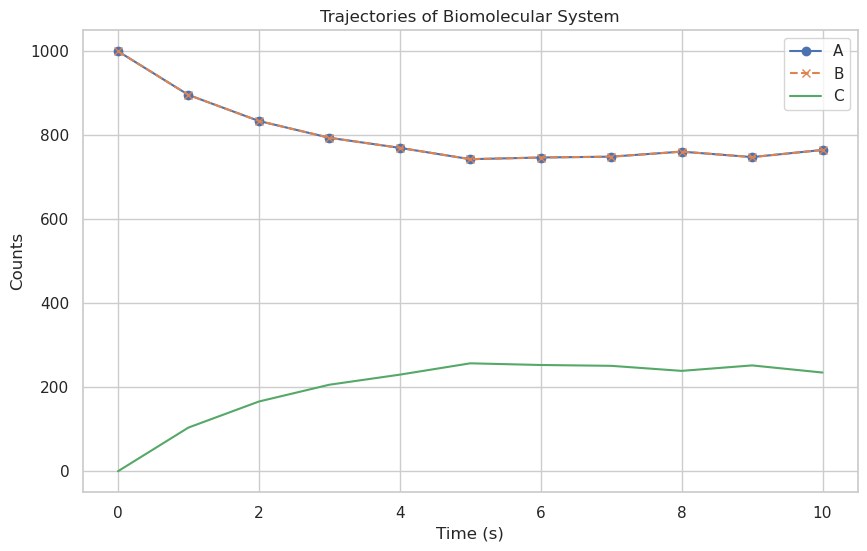

```python
# now visuzlize the trajectories with seaborn and plt
sns.set(style="whitegrid")
# Create a color palette
palette = sns.color_palette()
plt.figure(figsize=(10,6))
plt.plot(ts, As, label='A',marker='o', linestyle='-',color=palette[0])
plt.plot(ts, Bs, label='B',marker='x', linestyle='--',color=palette[1])
plt.plot(ts, Cs, label='C',color=palette[2])

plt.title('Trajectories of Biomolecular System')
plt.xlabel('Time (s)')
plt.ylabel('Counts')
plt.legend()
plt.show()
```